# STA 141A Project 2

Group 5: Ally Deremer, Eshna Prakash, Jose Lopez, Jasper Cheng

3/5/2021

# Abstract

COVID-19 is a new coronavirus strain that emerged at the end of 2019. It is a highly infectious virus and there is currently no cure. Many countries have responded to this global pandemic by implementing preventative measures such as lockdowns, facial mask mandates and social distancing. The specifics such as timing and effectiveness of each country’s response has varied widely. This report does a thorough analysis on how case fatality rate (CFR) varied over twelve different countries. Polynomial regression was fitted along with ANOVA modeling to analyze the data set. Sensitivity analysis confirmed correct model assumptions and fitting. Although there were limitations within this report, statistical analyses were able to conclude that there is a difference in CFR over time for different countries.

# Introduction

The dataset utilized in this study is from the World Health Organization (WHO) in the format of an excel file that is updated on a daily basis. The data set contains information about COVID-19 cases for each of the 237 countries data was collected from. Data collection began January 3, 2020 and this report uses all data collected until March 1, 2021. The number of new cases, cumulative cases, new deaths and cumulative deaths are recorded for each day of data collection. The question of interest this report will focus on is, “Does Case Fatality Rate vary across different countries?”.

# Background

Coronavirus is a highly contagious respiratory illness which is also known as COVID-19. This virus spreads through droplets in the air when an infected person coughs or sneezes. There is no specific treatment for the virus and laboratory tests are required for confirmation of diagnosis. While most recover from COVID-19, some have symptoms that last for weeks or even months after recovering from acute illness. The long term effects of COVID-19 are not currently known and it is being investigated. Those with a higher risk of dying from COVID-19 and related complications are older people and those with underlying medical conditions. Prevention measures that can be taken against this virus include wearing facial coverings, frequent washing of hands and social distancing. In order to reduce the severity of the pandemic, limiting contact between infected individuals is important. Since the primary route of transmission of coronavirus is through respiratory particles, there is overwhelming evidence that mask wearing " reduces transmissibility per contact by reducing transmission of infected respiratory particles" (Howard et al., 2021).The CDC states that the more people and longer time an individual interacts with, the higher the potential risk of contracting and spreading COVID-19. (“Community Mitigations”, 2021). Guidelines regarding social gatherings are based upon national, state and local laws and regulations. Currently, there is an increase in global coronavirus cases which may be due to public health restrictions being lifted in addition to new coronavirus variants.(WHO, 2021). Multiple vaccines have been developed for emergency use and over 245 million doses have been administered in 107 countries.

# Descriptive Analysis

This report will not analyze every country from the WHO data set. The WHO regions include African Region (AFR), Regions of the Americas (AMR), South East Asian Region (SEAR), European Region (EUR), Eastern Mediterranean Region (EMR) and the Western Pacific Region (WPR). This report chose the two most populated countries for each WHO region. Therefore, this report looks at Nigeria, Ethiopia, US, Brazil, India, Indonesia, Russia, Turkey, Pakistan, Egypt, China and Japan. The time period selected to focus on was the 100 days after the 100th confirmed case of COVID-19. The purpose for this was to restrict the data set to verify all countries had at least 100 confirmed coronavirus cases to avoid influencing results due to small numbers (Sorci, Faivre, & Morand, 2020). Case Fatality Rate (CFR) is all deaths from the specific disease in the population divided by all cases of the disease in the population. It is important to note that CFR is not an accurate measure of the mortality risk of the disease during a pandemic.

```
## [1] "Date_reported"     "Country_code"      "Country"
## [4] "WHO_region"        "New_cases"         "Cumulative_cases"
## [7] "New_deaths"        "Cumulative_deaths" "CFR"
```

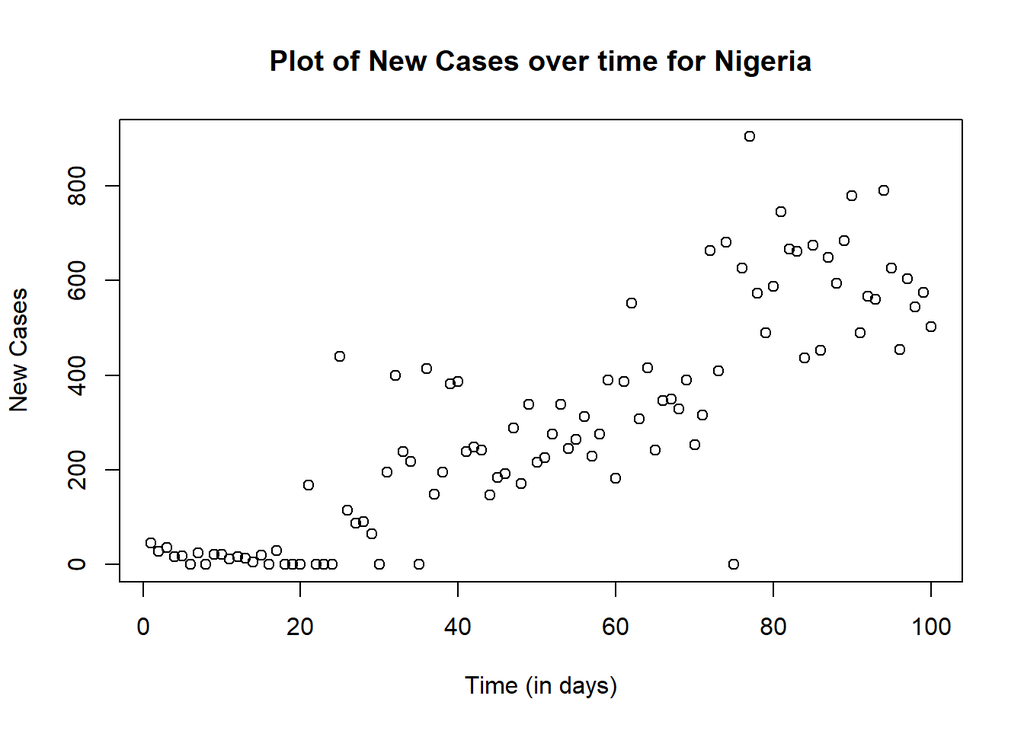

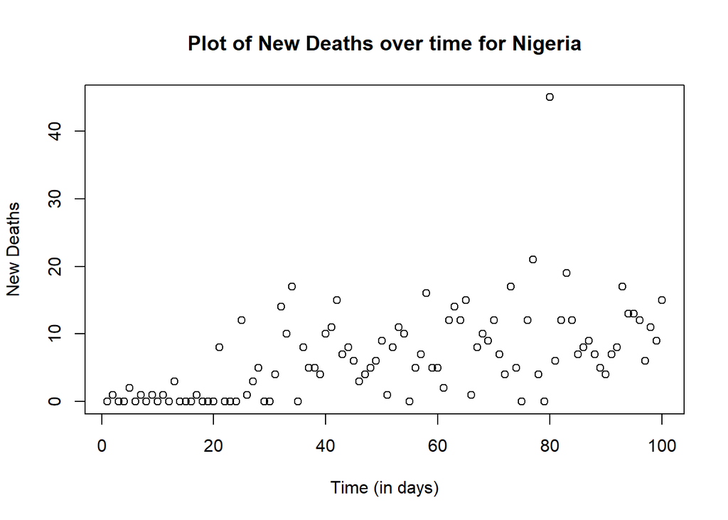

Plots for Ethiopia are shown below. Plot of new cases does not appear to be linear but has a positive trend. Plot of new deaths appears to have a positive trend of new deaths as time increases.

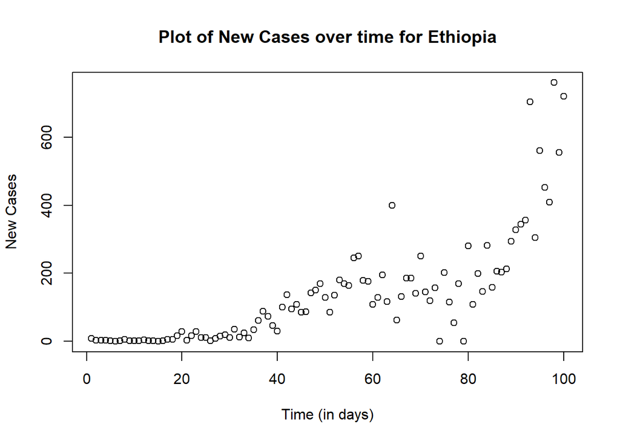

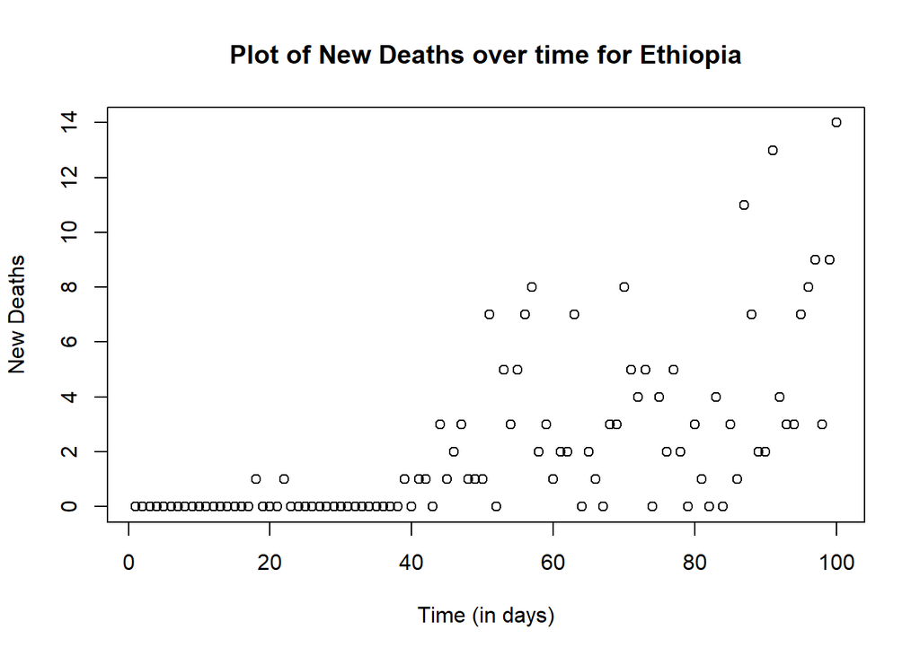

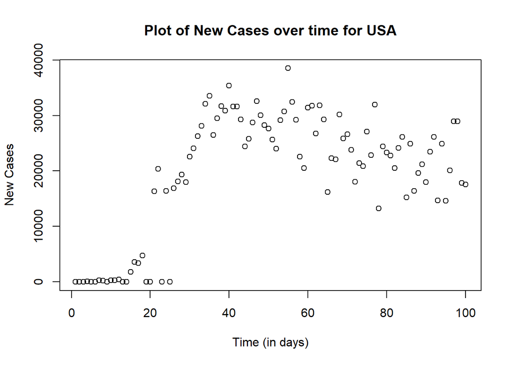

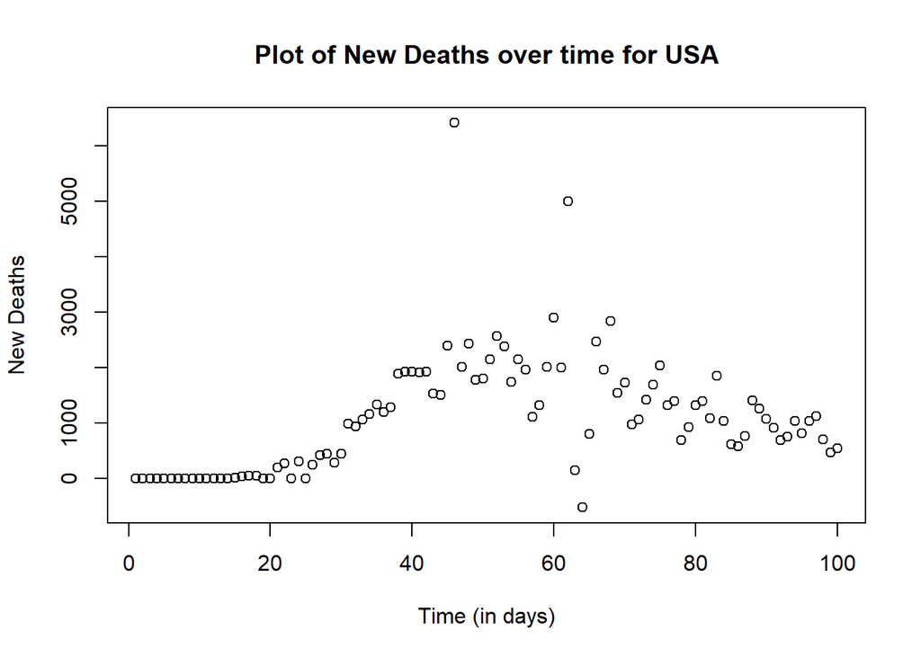

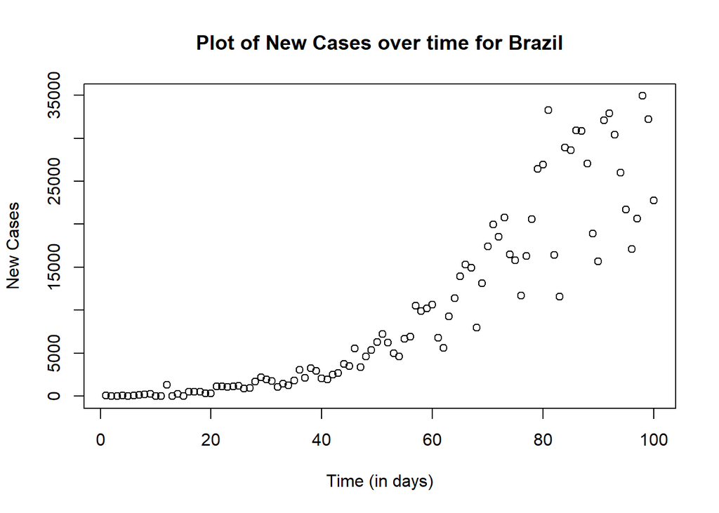

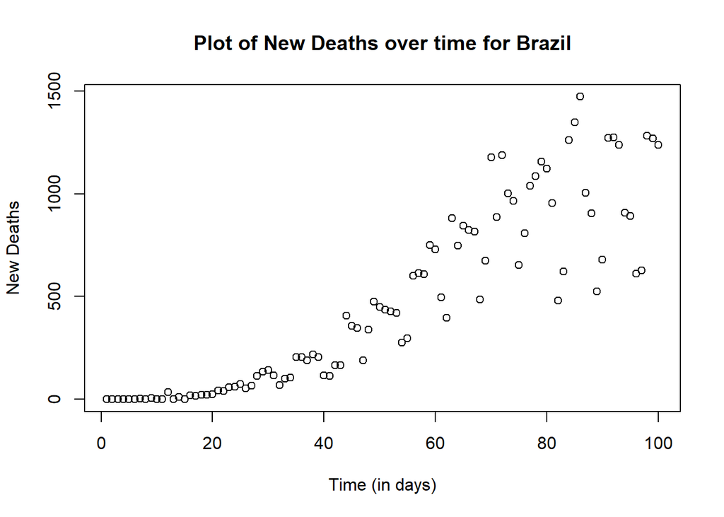

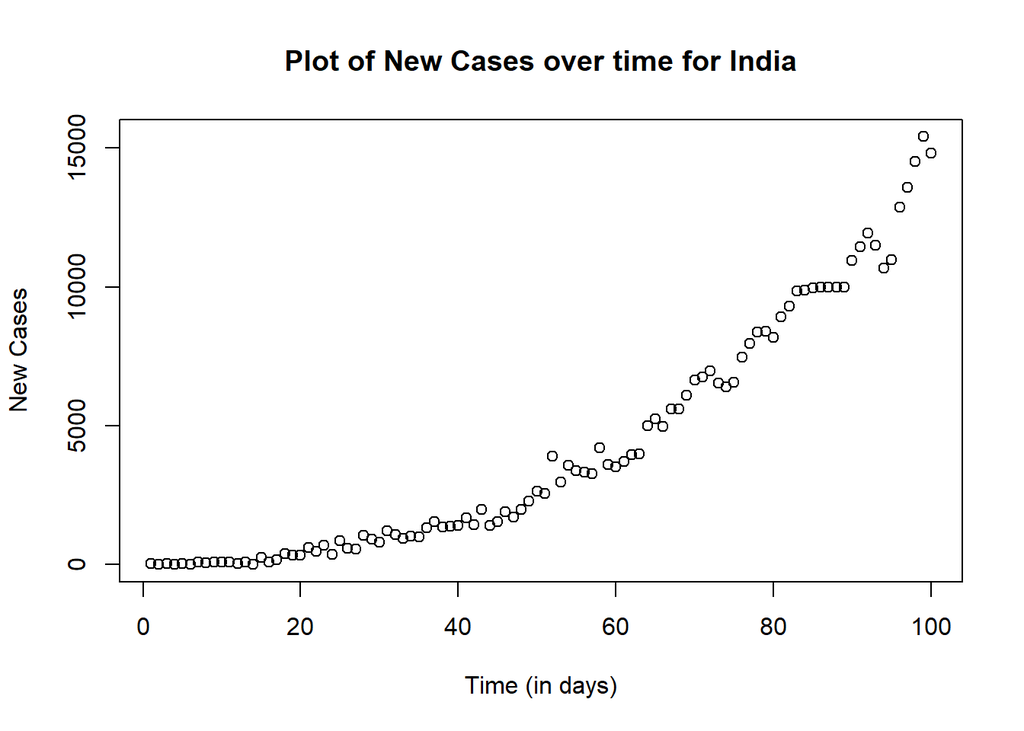

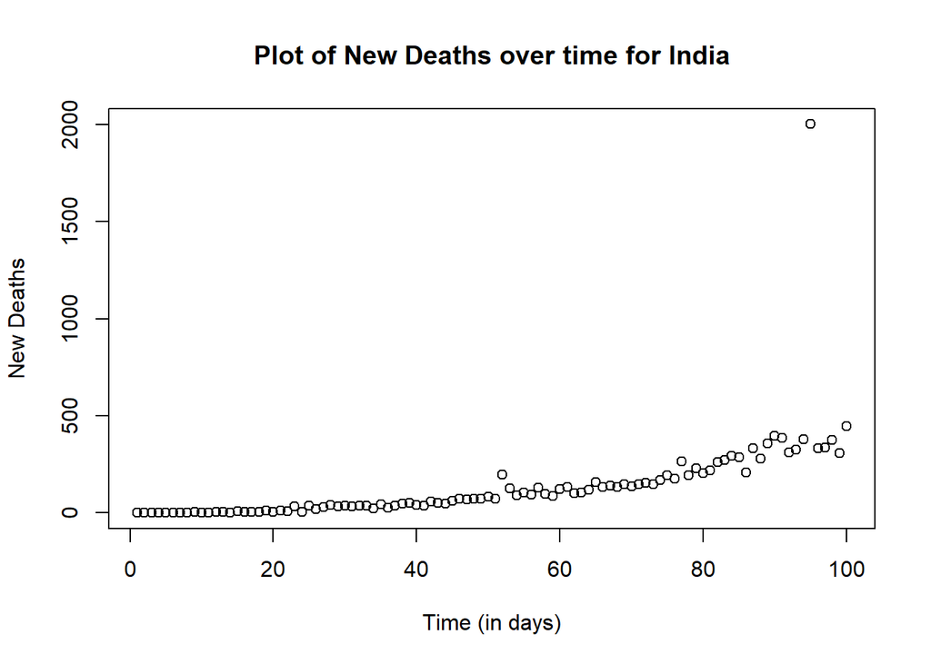

Plots for Indonesia are shown below. For new cases over time, it appears that there is a positive linear trend. For new deaths over time, there appears to be a slight positive linear trend with a few possible outliers.

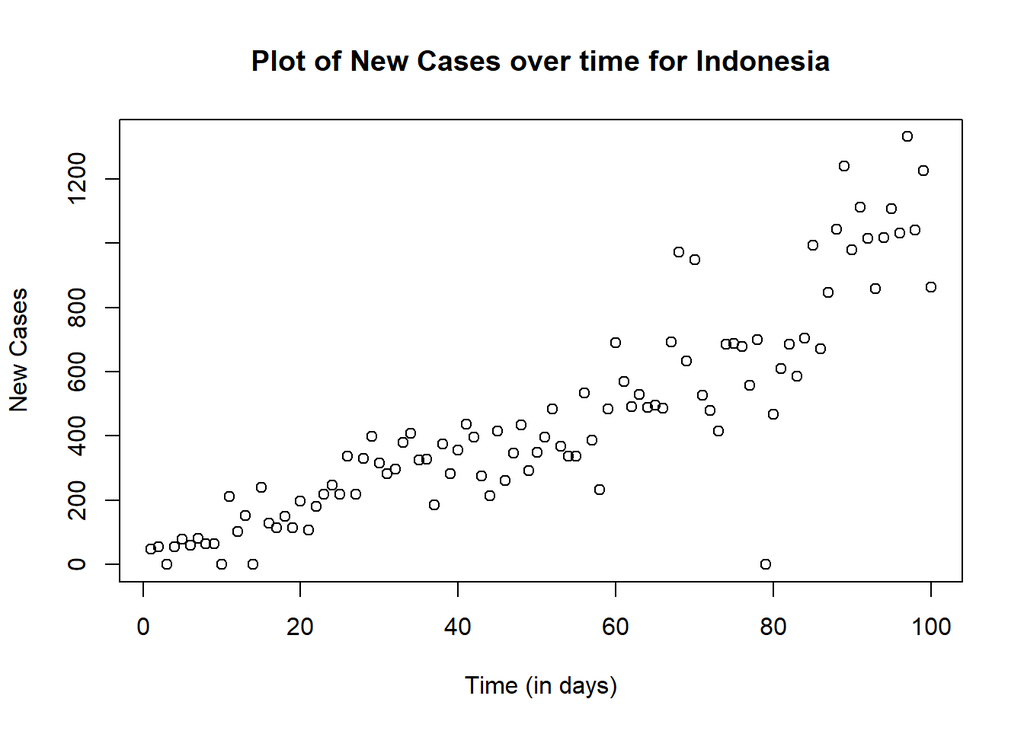

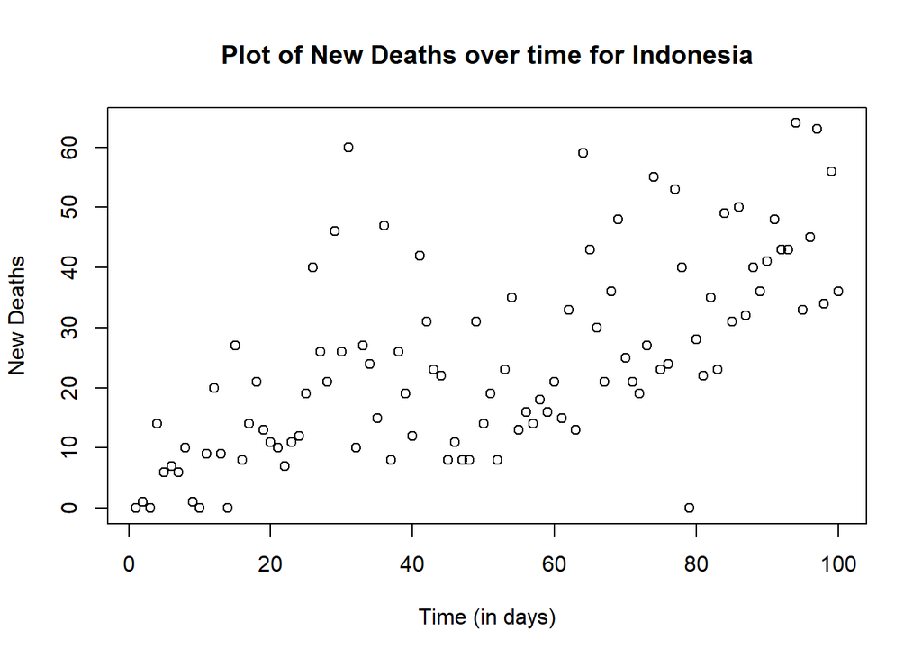

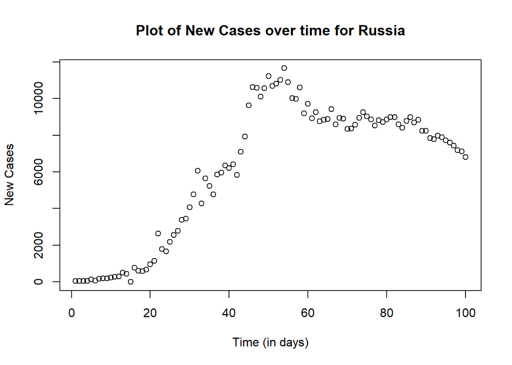

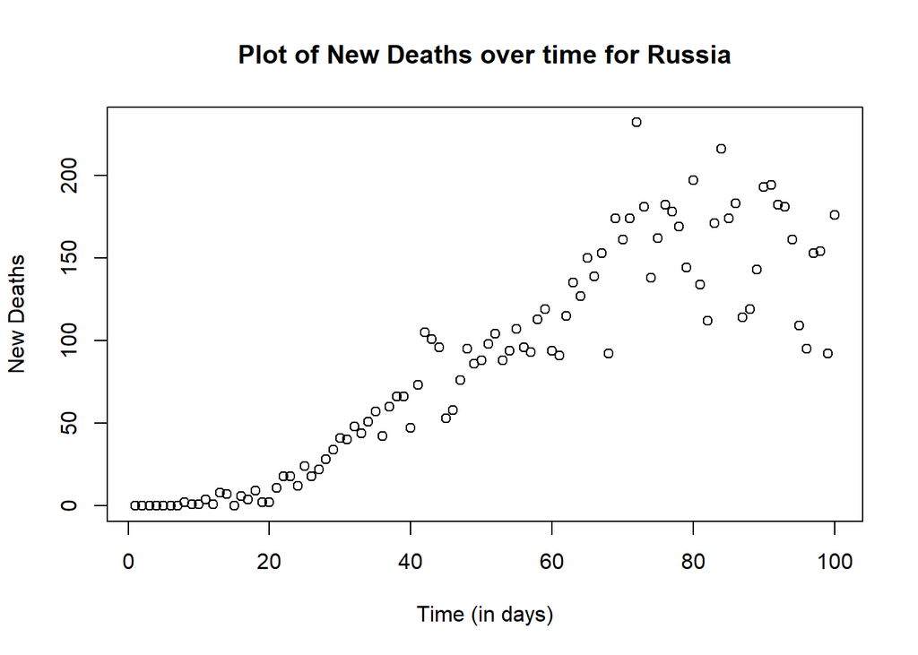

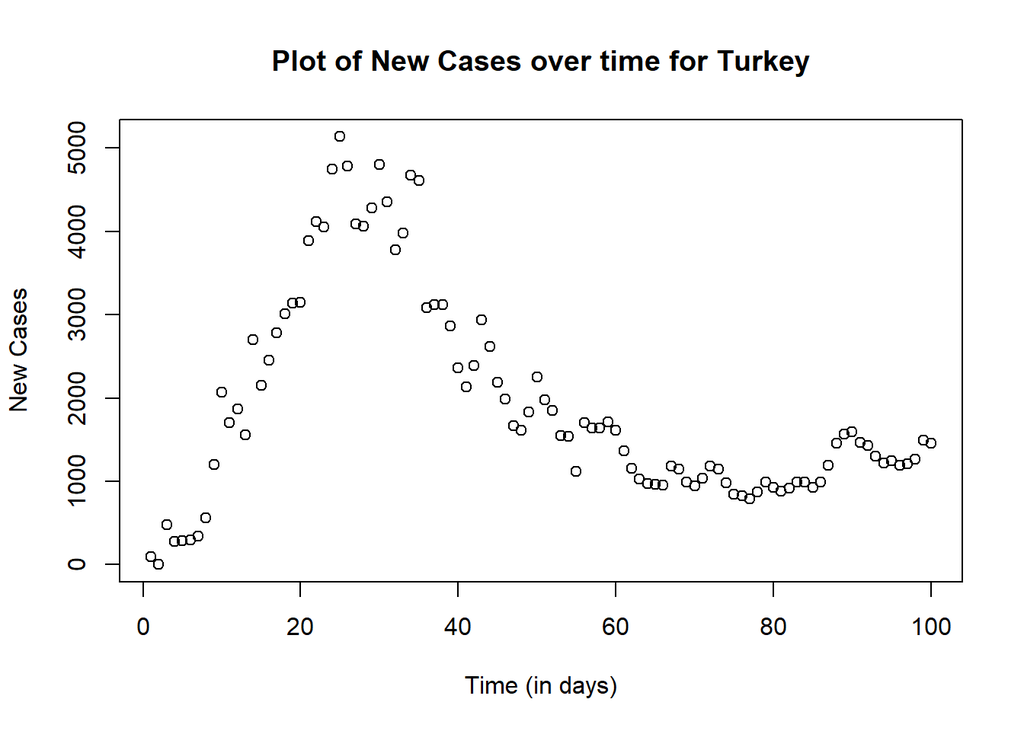

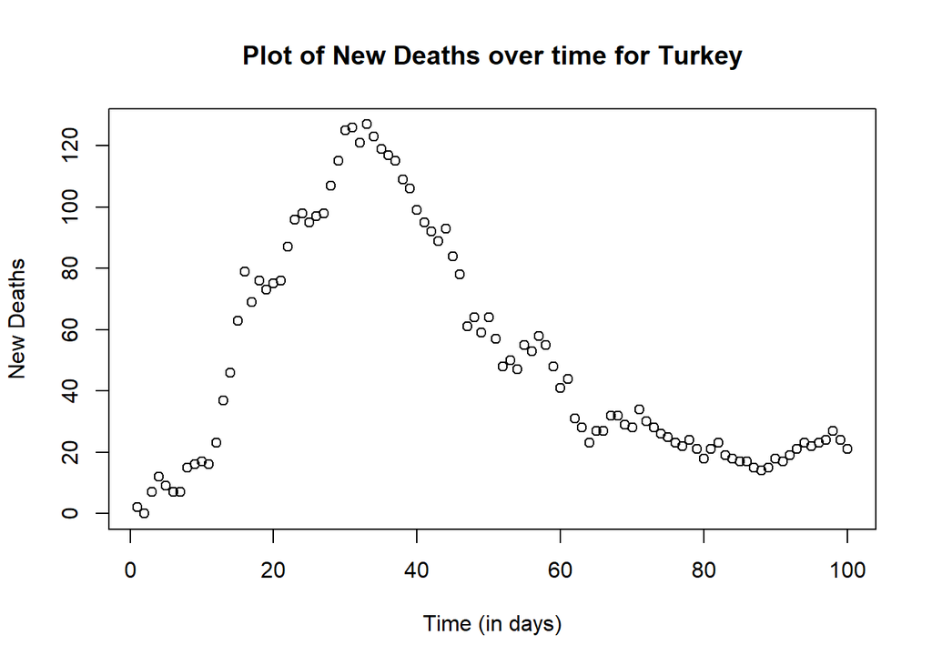

Plots for Pakistan are shown below. It is evident that there is no linear trend for both new cases over time and new deaths over time.

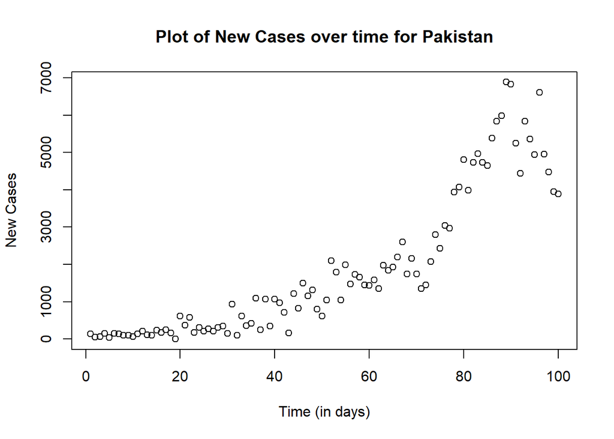

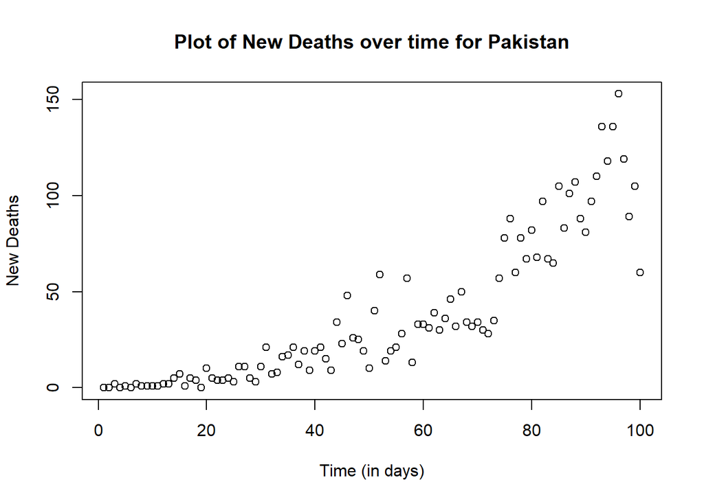

Plots for Egypt are shown below. For both plots, it is evident that there is not a linear trend.

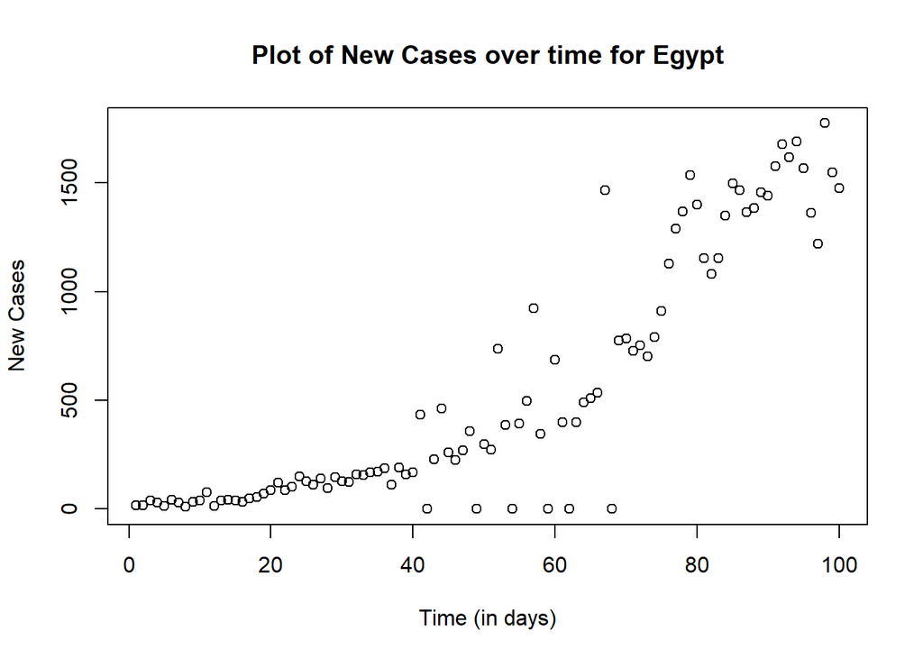

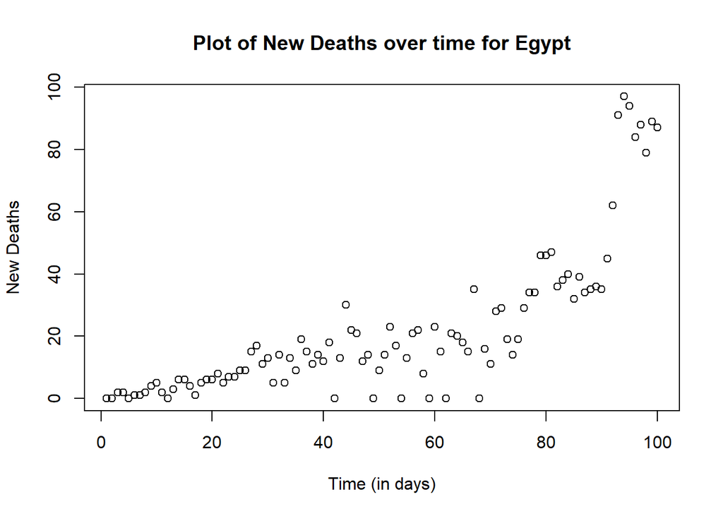

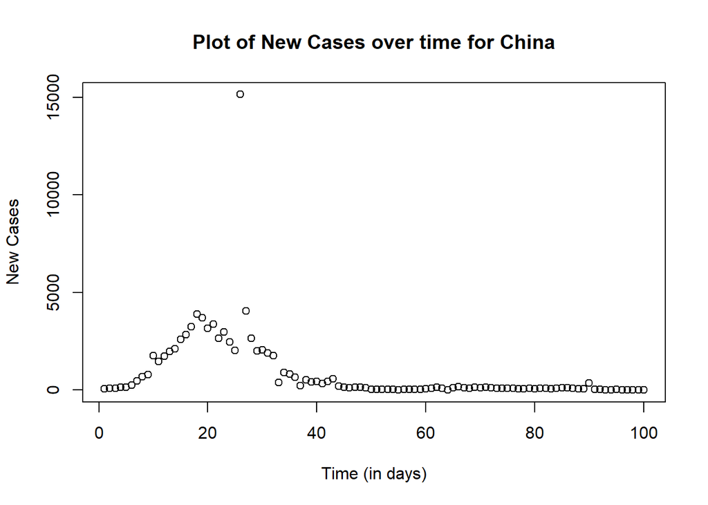

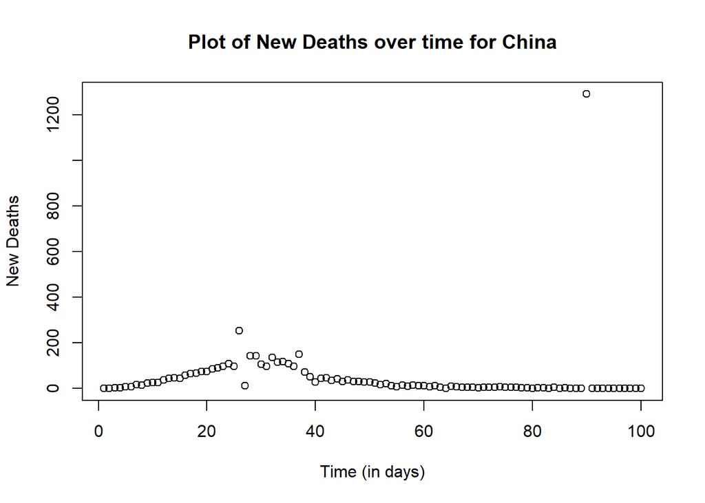

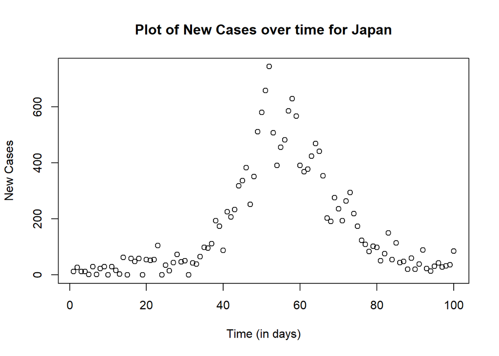

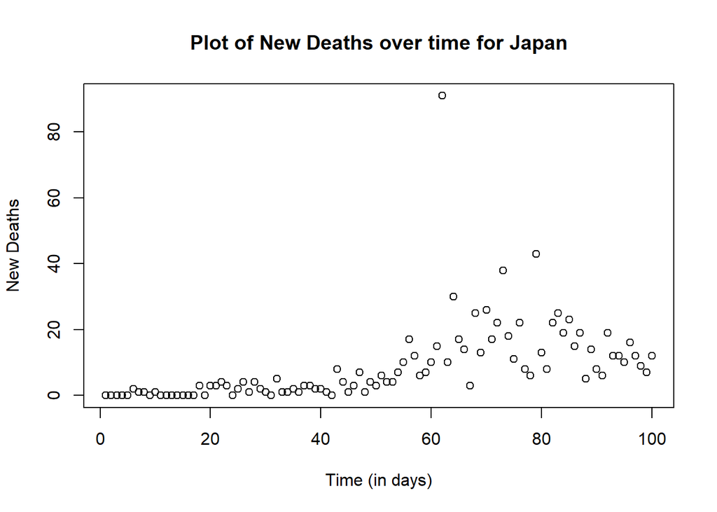

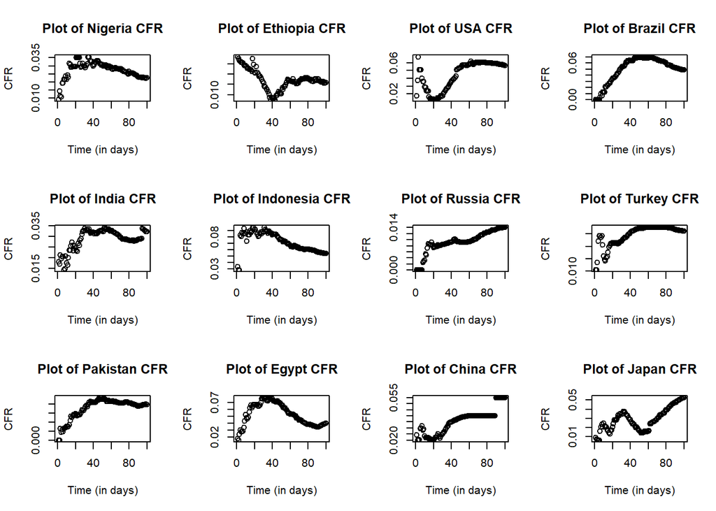

# Statistical Approach

For statistical analysis, regression modeling will be employed. Through the descriptive analysis, it has been learned that data points are scattered mostly in a non-linear faction across every country under observation. Therefore, polynomial regression will be fitted according to human intuition. As it is known, there is a trade off between variance and bias for polynomial regression. While a high degree regression may represent every data point accurately, it does not necessarily reflect a meaningful trend and is incomparable to other regressions. Hence, the degree of polynomial regression is considered under a low bias, low variance basis, instead of sacrificing one for the other.

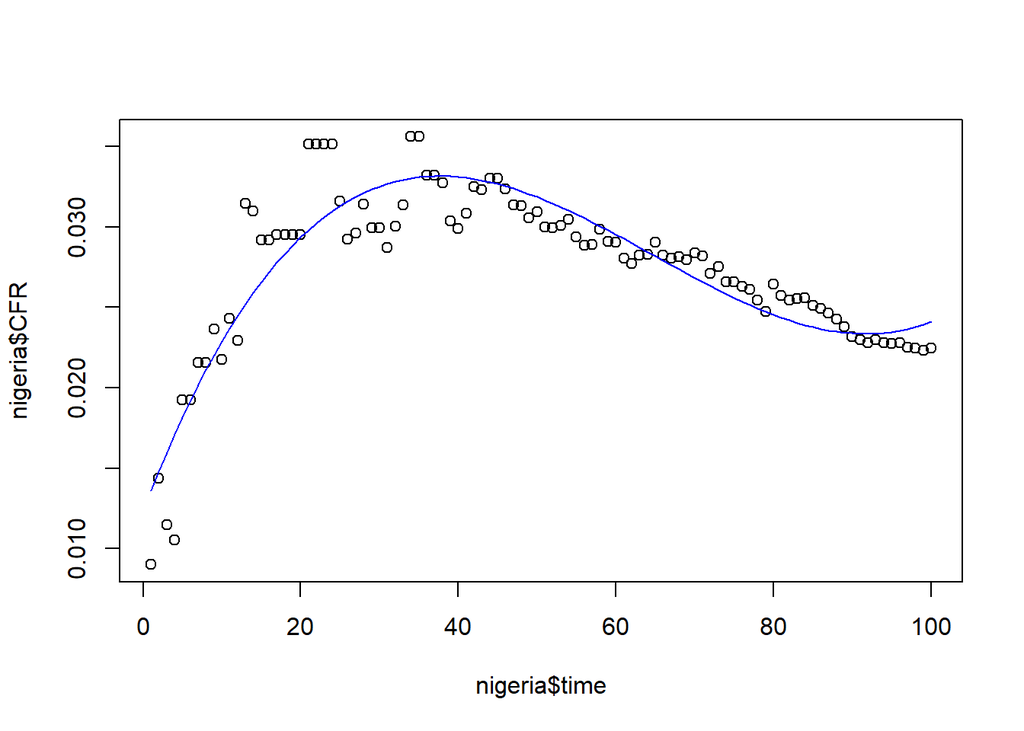

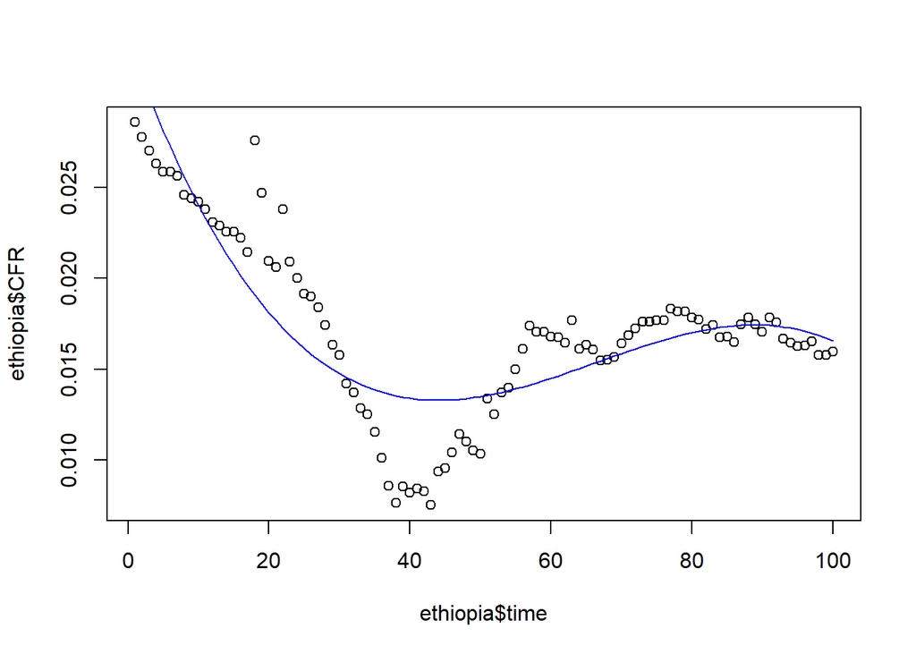

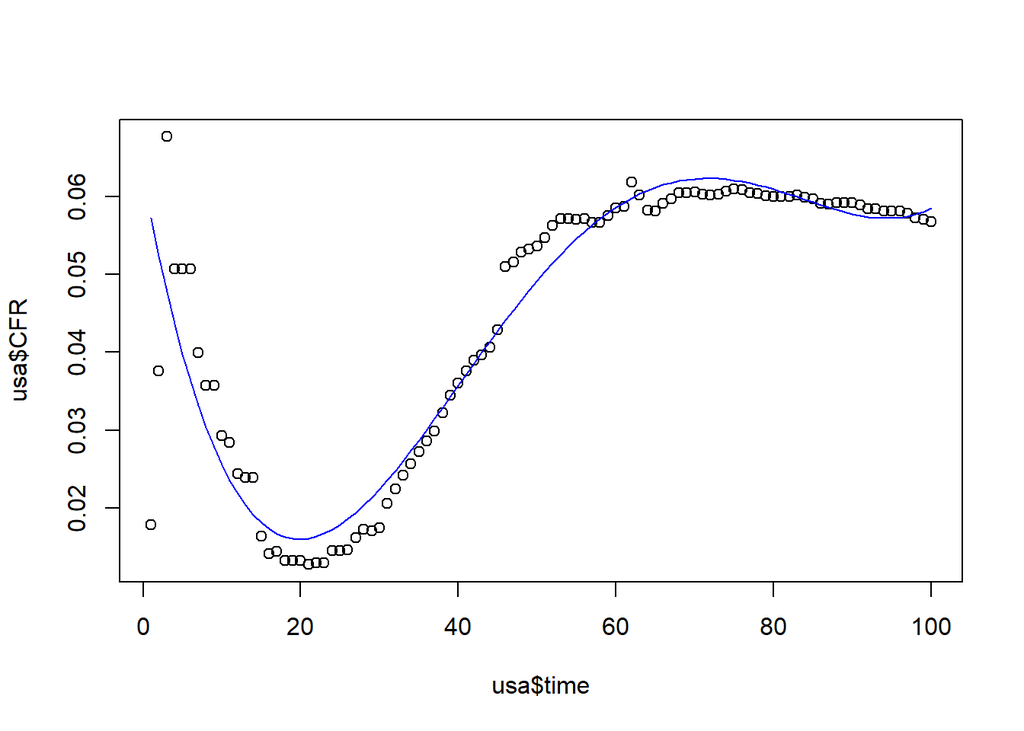

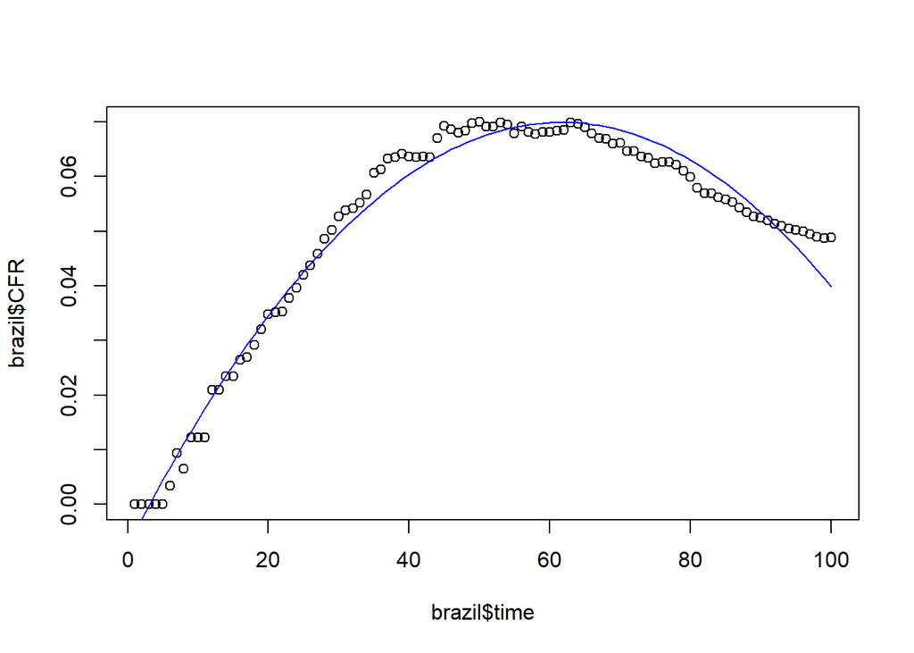